# 智能技術之股票波動率分析

鄭淵哲，李峻瑋

報告時間：2020/06/16

# (1) (KDD1) 數據取得

- (1.1.1) 數據取得

> > 交易數據樣貌為:

> > | X | Code | Company | Date | Open | High | Low | Close | 成交额 | 成交量 | Rc | group |
> > | --- | --- | --- | --- | --- | --- | --- | --- | --- | --- | --- | --- |
> > | 1 | ABIO.O | 方舟生物医药 | 2019-04-01 | 7.38 | 7.73 | 7.36 | 7.53 | 0 | 213632 | 0.0201214 | 1 |
> > | 2 | ABIO.O | 方舟生物医药 | 2019-04-02 | 7.42 | 7.42 | 6.63 | 6.89 | 0 | 1459235 | -0.0741080 | 1 |

# (2) (KDD2) 數據探索

## (2.1) (KDD2) 日期探索

- (2.1.1) 交易數據的日期範圍為: 2019-04-01–2020-04-01

## (2.2) (KDD2) 收盤開盤價格探索

- (2.2.1) 說明：昨日收盤價不一定等於今日開盤價

> > Code Date Open Close

ABIO.O 4/1 7.38 7.53

ABIO.O 4/2 7.42 6.89

ABIO.O 4/3 6.97 6.83

ABIO.O 4/4 5.71 5.62

ABIO.O 4/5 5.56 5.71

# (2a) 股市分析

# (3) (KDD3) 數據轉換 (從 log(Close) - log(Open), 計算Rc)

|  | 2019-04-01 | 2019-04-02 | 2019-04-03 | 2019-04-04 | 2019-04-05 | 2019-04-08 | 2019-04-09 | 2019-04-10 | 2019-04-11 | 2019-04-12 | 2019-04-15 | 2019-04-16 | 2019-04-17 | 2019-04-18 | 2019-04-22 | 2019-04-23 | 2019-04-24 | 2019-04-25 | 2019-04-26 | 2019-04-29 | 2019-04-30 | 2019-05-01 | 2019-05-02 | 2019-05-03 | 2019-05-06 | 2019-05-07 | 2019-05-08 | 2019-05-09 | 2019-05-10 | … |
| --- | --- | --- | --- | --- | --- | --- | --- | --- | --- | --- | --- | --- | --- | --- | --- | --- | --- | --- | --- | --- | --- | --- | --- | --- | --- | --- | --- | --- | --- | --- |
| ACHIEVE LIFE SCIENCES | -0.0217738 | -0.0459499 | 0.0517619 | 0.0467922 | 0.0385723 | 0.0133513 | 0.0052910 | 0 | 0 | 0 | 0 | 0 | 0 | 0 | 0 | 0 | 0 | 0 | 0 | 0 | 0 | 0 | 0 | 0 | 0 | 0 | 0 | 0 | 0 | … |
| ADAPTIMMUNE THERAPEUTICS | -0.0137302 | 0.0479395 | 0.1113344 | -0.0663011 | 0.0198419 | -0.0218914 | -0.0879227 | 0 | 0 | 0 | 0 | 0 | 0 | 0 | 0 | 0 | 0 | 0 | 0 | 0 | 0 | 0 | 0 | 0 | 0 | 0 | 0 | 0 | 0 | … |
| ADMA BIOLOGICS | 0.0173486 | -0.2128137 | -0.0077821 | -0.0057637 | -0.0271861 | 0.0580744 | 0.0019589 | 0 | 0 | 0 | 0 | 0 | 0 | 0 | 0 | 0 | 0 | 0 | 0 | 0 | 0 | 0 | 0 | 0 | 0 | 0 | 0 | 0 | 0 | … |
| BOOKING | 0.0023618 | -0.0014053 | -0.0019925 | 0.0029753 | -0.0104457 | 0.0116966 | 0.0099239 | 0 | 0 | 0 | 0 | 0 | 0 | 0 | 0 | 0 | 0 | 0 | 0 | 0 | 0 | 0 | 0 | 0 | 0 | 0 | 0 | 0 | 0 | … |
| CASEYS GENERAL STORES | -0.0006243 | -0.0040714 | 0.0048279 | -0.0011642 | 0.0052644 | -0.0067403 | -0.0068842 | 0 | 0 | 0 | 0 | 0 | 0 | 0 | 0 | 0 | 0 | 0 | 0 | 0 | 0 | 0 | 0 | 0 | 0 | 0 | 0 | 0 | 0 | … |

- (3.1.1) 說明：為何要取Log？而不是使用(Close - Open)/Open?

Example:

第一年 第二年 第三年 第四年 第五年

50 100 50 100 50

0 +100% -50% +100% -50% 平均25%收益率 （使用(Close - Open)/Open）

※表面上平均收益有25%但是股票數值第一年跟第五年是一樣的

# (4) (KDD4) 數據模型

## (4.1) (KDD4) 波動率聚類 (Volatility, group)

```
## Volatility.group
##  1  2  3  4  5
##  4  2  5 10  4
```

> > Biotechnolo: 方舟: 1 / 阿卡迪亞: 5 / ACHIEVE LIFE: 1 / ADAPTI: 1 / ADMA: 2

> > PC hardware: APPLE: 3 / 慧與: 4 / 惠普: 4 / NCR: 5 / STRA: 4

> > Aviation: 美國航空: 5 / 達美航空: 4 / 阿拉斯加航空: 4 / 聯合航空: 5 / 梅薩航空: 2

> > E-commerce: 亞馬遜: 3 / 阿里巴巴: 3 / BOOKING: 3 / EBAY: 3 / 京東: 4

> > Food Retail: 中國城超市: 1 / CASEY: 4 / 阿格萊斯: 4 / SPROUTS FARMERS: 4 / VILLAGE SUPER: 4

## (4.2) (KDD4) Beta指數 (Volatility, Beta)

- (4.2.1) Beta數據樣貌為:

  | Code | Beta | Company | industry |
  | --- | --- | --- | --- |
  | ABIO.O | 1.7339 | 方舟生物醫藥 | biotechnology |
  | ACAD.O | 0.2490 | 阿卡迪亞 | biotechnology |
  | ACHV.O | -0.7799 | ACHIEVE LIFE SCIENCES | biotechnology |
  | ADAP.O | 1.9583 | ADAPTIMMUNE THERAPEUTICS | biotechnology |
  | ADMA.O | 0.6960 | ADMA BIOLOGICS | biotechnology |
  | AAPL.O | 1.2326 | APPLE | PC hardware |
  | HPE.N | 1.4205 | 慧與 | PC hardware |
  | HPQ.N | 1.1134 | 惠普公司 | PC hardware |
  | NCR.N | 1.9160 | NCR | PC hardware |
  | SYS.O | 0.6794 | STRATASYS | PC hardware |
  | AAL.O | 2.7703 | 美國航空 | aviation |
  | DAL.N | 2.3912 | 達美航空 | aviation |
  | ALK.N | 2.6814 | 阿拉斯加航空 | aviation |
  | UAL.O | 3.0185 | UNITED AIRLINES | aviation |
  | MESA.O | 2.9184 | 梅薩航空 | aviation |
  | AMZN.O | 0.3591 | 亞馬遜 | E-commerece |
  | BABA.N | 0.9098 | 阿里巴巴 | E-commerece |
  | BKNG.O | 1.2856 | BOOKING | E-commerece |
  | EBAY.O | 0.6438 | EBAY | E-commerece |
  | JD.O | 0.6438 | 京東 | E-commerece |
  | IFMK.O | -5.2159 | IFRESH | Food Retail |
  | IMKTA.O | 0.4447 | 阿格萊斯市場 | Food Retail |
  | SFM.O | -0.5666 | SPROUTS FARMERS MARKET | Food Retail |
  | VLGEA.O | -0.2136 | VILLAGE SUPER MARKET-CLASS A | Food Retail |
  | CASY.O | 0.6798 | CASEYS GENERAL STORES | Food Retail |

- (4.2.2) 說明：Beta = 相關係數 x 個股波動率 / 大盤波動率

Beta指數越低說明與大盤走勢越相反且波動率越大，此時波動率越大越是優質股。

Beta指數低的股票說明是雪中送炭的股票，而不是追漲殺跌、錦上添花的股票。

- (4.2.3) 可以看出在這25筆2019.4.1-2020.4.1的股票中 IFRESH的Beta指數最低，最值得購買。

## (4.3) (KDD4) 決策樹分類股票

- (4.3.1) 說明：利用波動率以及收益(increase)將五個行業分類來分析哪種行業是目前值得買的股票

> > 1: biotechnology

> > 2: PC hardware

> > 3: aviation

> > 4: E-commerece

> > 5: Food Retail

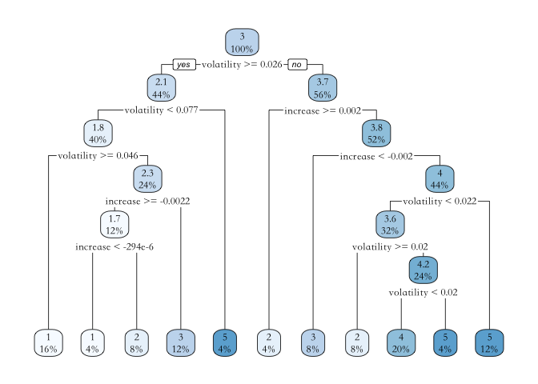

# (5) (KDD5) 數據初結

## (5.2) 波動率應用：交易決策

- (5.2.1) 配合大盤指數算出Beta指數，走勢與大盤相反，波動率大的股票就是優質股。簡單有效的針對波動率進行了交易決策。

## (5.3) 決策樹應用：行業分類

- (5.3.1) 用波動率跟收益來將行業分類，大致可以看出哪種行業的股票是目前風險最小且持續成長的。